# Potato Randomization Analysis

Dina Dinh

November 07, 2025

# Research Question: Is the relationship between LDL and HDL the same between treatment groups?

## Data Cleaning and Summary Statistics

I believe subject “A00-079493” is a typo and should be “A00-07-3493” also “A00-054384” should be “A00-05-4384”. However, since it is more evident for subject “A00-05-4384”, I will only be adjusting this typo.

|  | LMP VISIT 1 (N=17) | LMP VISIT 9 (N=17) | PLM VISIT 1 (N=18) | PLM VISIT 9 (N=14) |
| --- | --- | --- | --- | --- |
| VLDL & Chylomicron Particles (total) (nmol/L) |  |  |  |  |
| Mean (SD) | 47.0 (19.6) | 49.6 (22.8) | 43.3 (19.7) | 51.6 (23.9) |
| Median [Min, Max] | 45.8 [12.3, 81.6] | 50.1 [10.6, 87.1] | 42.1 [6.10, 80.4] | 51.9 [16.7, 94.8] |
| Large VLDL & Chylomicron Particles (nmol/L) |  |  |  |  |
| Mean (SD) | 4.39 (3.54) | 4.48 (2.78) | 4.53 (4.69) | 5.09 (4.22) |
| Median [Min, Max] | 3.20 [0.600, 14.0] | 4.10 [1.00, 10.0] | 3.20 [0.500, 19.3] | 4.05 [0.200, 15.9] |
| Medium VLDL Particles (nmol/L) |  |  |  |  |
| Mean (SD) | 12.7 (8.53) | 15.7 (10.8) | 10.5 (9.66) | 17.0 (12.3) |
| Median [Min, Max] | 10.7 [2.20, 25.6] | 12.0 [0, 35.3] | 8.20 [0, 36.8] | 13.4 [0.200, 39.4] |
| Small VLDL Particles (nmol/L) |  |  |  |  |
| Mean (SD) | 29.9 (12.7) | 29.4 (13.0) | 28.3 (14.8) | 29.6 (15.6) |
| Median [Min, Max] | 31.4 [5.60, 53.7] | 29.9 [4.60, 54.0] | 26.9 [5.50, 55.3] | 28.7 [6.70, 69.2] |
| LDL Particles (total) (nmol/L) |  |  |  |  |
| Mean (SD) | 1110 (215) | 1160 (255) | 1010 (297) | 1060 (289) |
| Median [Min, Max] | 1080 [812, 1560] | 1110 [841, 1820] | 1000 [507, 1780] | 1040 [657, 1540] |
| IDL Particles (nmol/L) |  |  |  |  |
| Mean (SD) | 164 (81.7) | 203 (127) | 127 (76.0) | 239 (131) |
| Median [Min, Max] | 168 [15.0, 328] | 138 [48.0, 446] | 122 [40.0, 336] | 208 [41.0, 499] |
| Large LDL Particles (nmol/L) |  |  |  |  |
| Mean (SD) | 324 (203) | 255 (201) | 254 (162) | 160 (147) |
| Median [Min, Max] | 329 [0, 777] | 231 [0, 744] | 218 [0, 513] | 108 [0, 452] |
| Small LDL Particles (total) (nmol/L) |  |  |  |  |
| Mean (SD) | 624 (214) | 698 (215) | 627 (204) | 657 (240) |
| Median [Min, Max] | 642 [72.0, 900] | 706 [77.0, 1100] | 654 [291, 1060] | 636 [365, 1180] |
| HDL Particles (total) (µmol/L) |  |  |  |  |
| Mean (SD) | 31.2 (4.74) | 27.1 (3.57) | 32.8 (6.41) | 28.9 (3.55) |
| Median [Min, Max] | 29.5 [25.1, 41.4] | 26.4 [17.7, 32.8] | 33.4 [20.5, 45.6] | 29.4 [21.5, 33.9] |
| Large HDL Particles (µmol/L) |  |  |  |  |
| Mean (SD) | 6.75 (2.16) | 5.66 (2.24) | 7.32 (2.78) | 6.83 (2.60) |
| Median [Min, Max] | 6.70 [3.80, 10.6] | 4.90 [3.40, 12.0] | 5.90 [3.40, 12.2] | 6.50 [3.50, 11.4] |
| Medium HDL Particles (µmol/L) |  |  |  |  |
| Mean (SD) | 10.8 (4.96) | 9.06 (3.57) | 12.3 (7.20) | 9.94 (6.38) |
| Median [Min, Max] | 9.60 [2.90, 21.7] | 8.60 [2.80, 15.3] | 10.7 [2.70, 34.1] | 9.90 [0.800, 20.3] |
| Small HDL Particles (µmol/L) |  |  |  |  |
| Mean (SD) | 13.7 (5.97) | 12.4 (2.48) | 13.3 (6.10) | 12.1 (7.11) |
| Median [Min, Max] | 13.7 [0.200, 24.0] | 12.4 [7.30, 15.6] | 14.1 [0, 25.5] | 11.2 [1.50, 23.8] |
| VLDL Size (nm) |  |  |  |  |
| Mean (SD) | 48.4 (6.72) | 50.0 (6.61) | 50.6 (8.99) | 49.7 (6.08) |
| Median [Min, Max] | 46.6 [37.6, 65.6] | 49.6 [40.1, 65.3] | 48.4 [37.4, 70.5] | 50.8 [37.6, 61.1] |
| Missing | 0 (0%) | 1 (5.9%) | 1 (5.6%) | 0 (0%) |
| LDL Size (nm) |  |  |  |  |
| Mean (SD) | 20.8 (0.713) | 20.4 (0.565) | 20.6 (0.530) | 20.3 (0.524) |
| Median [Min, Max] | 20.6 [19.7, 21.8] | 20.2 [19.6, 21.6] | 20.7 [19.7, 21.7] | 20.4 [19.6, 21.2] |
| HDL Size (nm) |  |  |  |  |
| Mean (SD) | 9.42 (0.443) | 9.32 (0.419) | 9.51 (0.359) | 9.46 (0.398) |
| Median [Min, Max] | 9.40 [8.80, 10.4] | 9.20 [8.90, 10.4] | 9.60 [8.80, 10.1] | 9.50 [8.90, 9.90] |
| Lipoprotein Insulin Resistance Score |  |  |  |  |
| Mean (SD) | 42.4 (19.4) | 49.6 (17.1) | 44.1 (19.7) | 45.9 (17.2) |
| Median [Min, Max] | 42.0 [5.00, 81.0] | 54.0 [18.0, 84.0] | 40.0 [8.00, 82.0] | 43.0 [12.0, 74.0] |
| Total Cholesterol (mg/dL) |  |  |  |  |
| Mean (SD) | 190 (26.1) | 180 (33.0) | 182 (30.3) | 182 (29.1) |
| Median [Min, Max] | 196 [144, 236] | 176 [128, 260] | 174 [118, 234] | 176 [146, 229] |
| HDL Cholesterol (mg/dL) |  |  |  |  |
| Mean (SD) | 48.2 (8.15) | 42.1 (8.79) | 50.3 (13.7) | 46.6 (10.6) |
| Median [Min, Max] | 45.0 [39.0, 62.0] | 39.0 [35.0, 69.0] | 46.5 [31.0, 76.0] | 44.0 [33.0, 63.0] |
| Triglycerides (mg/dL) |  |  |  |  |
| Mean (SD) | 103 (48.5) | 106 (36.9) | 112 (91.8) | 111 (50.5) |
| Median [Min, Max] | 96.0 [51.0, 241] | 112 [51.0, 157] | 84.0 [42.0, 436] | 108 [54.0, 230] |
| ApoB (mg/dL) |  |  |  |  |
| Mean (SD) | 102 (13.6) | 101 (18.0) | 94.4 (15.4) | 96.1 (17.4) |
| Median [Min, Max] | 104 [75.0, 124] | 97.0 [72.0, 136] | 88.0 [73.0, 131] | 94.5 [72.0, 129] |
| LDL Cholesterol (mg/dL) |  |  |  |  |
| Mean (SD) | 123 (24.9) | 119 (28.8) | 112 (28.2) | 115 (27.3) |
| Median [Min, Max] | 130 [80.0, 158] | 115 [77.0, 179] | 103 [65.0, 174] | 108 [82.0, 166] |
| VLDL Cholesterol (mg/dL) |  |  |  |  |
| Mean (SD) | 18.6 (8.01) | 19.4 (6.19) | 19.9 (14.0) | 20.3 (8.78) |
| Median [Min, Max] | 17.0 [10.0, 40.0] | 20.0 [10.0, 28.0] | 15.5 [8.00, 68.0] | 19.5 [10.0, 41.0] |
| Non HDL Cholesterol (mg/dL) |  |  |  |  |
| Mean (SD) | 142 (23.6) | 138 (28.9) | 132 (28.6) | 136 (30.4) |
| Median [Min, Max] | 140 [101, 174] | 136 [93.0, 191] | 129 [87.0, 200] | 133 [94.0, 193] |

Since our main focus is the LDL and HDL particle relationship between the diet groups, we’ll plot those relationships.

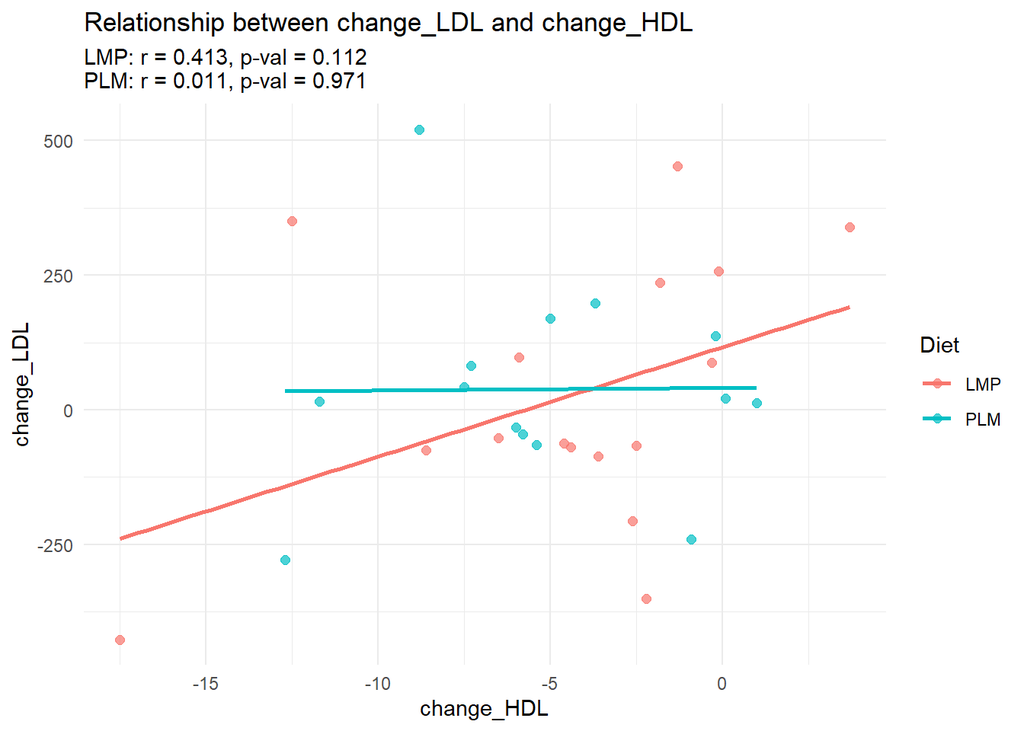

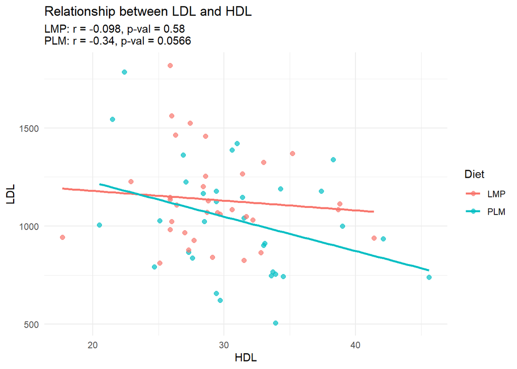

There seems to be a relationship between LDL and HDL for the PLM diet group but not for the LMP group based on the correlation and p-value. Let’s take a look at the correlation of each diet group for each Visit time.

Again, the relationship between LDL and HDL is more noticeable for the PLM diet group versus LMP group.

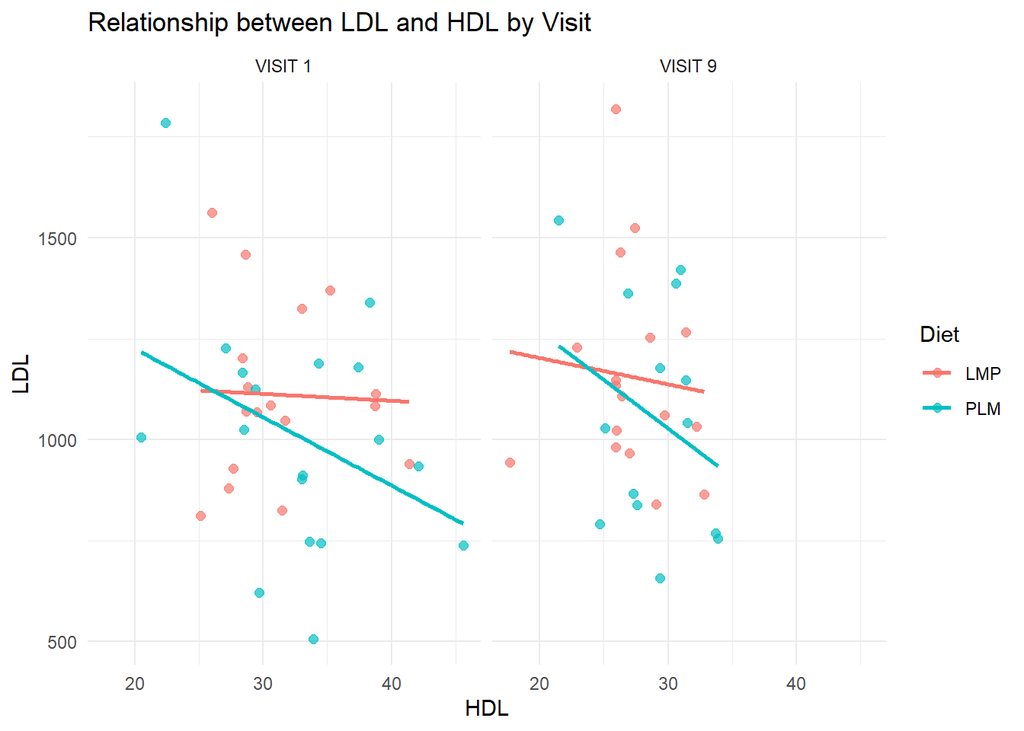

## Linear Mixed Models

Here, we will be using an unstructured covariance model.

In running the model, I found that subjects “A00-01-2009” and “A00-07-8983” have two visit 1 observations recorded. I will use the most recent Visit 1 observation of those participants.

### Full Model

model1 = mmrm(LDLP3 ~ 0 + Diet:Visit + HDLP3:Diet:Visit + us(Visit | SubjectID), data = df5)

#### Model Summary

```
## [1] "AIC: 838.57707209742"
```

```
## mmrm fit
##
## Formula:     LDLP3 ~ 0 + Diet:Visit + HDLP3:Diet:Visit + us(Visit | SubjectID)
## Data:        df5 (used 66 observations from 36 subjects with maximum 2
## timepoints)
## Covariance:  unstructured (3 variance parameters)
## Method:      Satterthwaite
## Vcov Method: Asymptotic
## Inference:   REML
##
## Model selection criteria:
##      AIC      BIC   logLik deviance
##    838.6    843.3   -416.3    832.6
##
## Coefficients:
##                            Estimate Std. Error       df t value Pr(>|t|)
## DietLMP:VisitVISIT 1        861.396    344.432   30.600   2.501  0.01796 *
## DietPLM:VisitVISIT 1       1383.135    295.244   37.390   4.685 3.65e-05 ***
## DietLMP:VisitVISIT 9        760.263    410.996   26.850   1.850  0.07538 .
## DietPLM:VisitVISIT 9       1599.851    524.456   32.060   3.050  0.00456 **
## DietLMP:VisitVISIT 1:HDLP3    8.037     10.851   29.920   0.741  0.46463
## DietPLM:VisitVISIT 1:HDLP3  -11.424      8.805   37.380  -1.297  0.20244
## DietLMP:VisitVISIT 9:HDLP3   14.240     14.975   26.410   0.951  0.35025
## DietPLM:VisitVISIT 9:HDLP3  -19.412     18.125   32.220  -1.071  0.29211
## ---
## Signif. codes:  0 '***' 0.001 '**' 0.01 '*' 0.05 '.' 0.1 ' ' 1
##
## Covariance estimate:
##          VISIT 1  VISIT 9
## VISIT 1 65529.25 43952.74
## VISIT 9 43952.74 74006.39
```

```
##
##  Shapiro-Wilk normality test
##
## data:  residuals(model1)
## W = 0.97354, p-value = 0.17
```

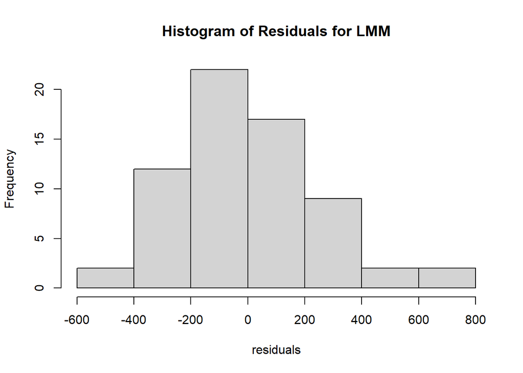

### Type III Test

```
## Analysis of Fixed Effect Table (Type III F tests)
##                  Num Df Denom Df F Statistic Pr(>=F)
## Diet:Visit            3   35.942     0.76747  0.5198
## Diet:Visit:HDLP3      4   31.461     0.82199  0.5210
```

Here, the type III test is testing if

1. $Diet_L,_9$ = $Diet_P,_9$ = $Diet_L,_1$ = $Diet_P,_1$ = 0 (Intercepts)
2. $Diet_L,_9$ = $Diet_P,_9$ = $Diet_L,_1$ = $Diet_P,_1$ = 0 (Slopes)

### Intercept Estimates

|  | Estimate | Std.Error |
| --- | --- | --- |
| LMP | 810.8295 | 288.6405 |
| PLM | 1491.4935 | 349.4274 |
| LMP VIST 1 | 861.3964 | 344.4323 |
| PLM VIST 1 | 1383.1355 | 295.2443 |
| LMP VIST 9 | 760.2626 | 410.9963 |
| PLM VIST 9 | 1599.8515 | 524.4560 |

### Tests for Intercept

All contrasts are in the format of LMP - PLM.

|  | Estimate | Std.Error | df | t.value | p.value |
| --- | --- | --- | --- | --- | --- |
| LMP - PLM : Overall | -57.79113 | 345.6510 | 28 | -0.1671950 | 0.8684183 |
| LMP: VIST 9-1 Intercept | -101.13379 | 491.7824 | 28 | -0.2056474 | 0.8385542 |
| PLM: VIST 9-1 Intercept | 216.71604 | 485.8483 | 28 | 0.4460570 | 0.6589865 |
| LMP - PLM : VIST 1 Intercept | -521.73907 | 453.6549 | 28 | -1.1500791 | 0.2598396 |
| LMP - PLM : VIST 9 Intercept | -839.58889 | 666.3123 | 28 | -1.2600532 | 0.2180513 |
| LMP - PLM : VIST 9-1 Intercept | 317.84982 | 691.3020 | 28 | 0.4597843 | 0.6492214 |

### Slope Estimates

|  | Estimate | Std.Error | df | t.value | p.value |
| --- | --- | --- | --- | --- | --- |
| LMP | 11.138770 | 9.910441 | 28.00000 | 1.1239429 | 0.2705813 |
| PLM | -15.418161 | 11.606310 | 28.00000 | -1.3284291 | 0.1947628 |
| LMP VIST 1 | 8.037484 | 10.850673 | 29.91833 | 0.7407360 | 0.4646278 |
| PLM VIST 1 | -11.424235 | 8.805414 | 37.37548 | -1.2974104 | 0.2024413 |
| LMP VIST 9 | 14.240055 | 14.974545 | 26.40725 | 0.9509508 | 0.3502525 |
| PLM VIST 9 | -19.412087 | 18.124514 | 32.21835 | -1.0710404 | 0.2921093 |

### Tests for Slope

All contrasts are in the format of LMP - PLM.

|  | Estimate | Std.Error | df | t.value | p.value |
| --- | --- | --- | --- | --- | --- |
| LMP - PLM : Overall | 0.8926405 | 11.87773 | 28 | 0.0751525 | 0.9406278 |
| LMP : VISIT 9-1 Slope | 6.2025706 | 17.06109 | 28 | 0.3635507 | 0.7189242 |
| PLM : VISIT 9-1 Slope | -7.9878515 | 16.53000 | 28 | -0.4832337 | 0.6326871 |
| LMP - PLM : VISIT 1 Slope | 19.4617197 | 13.97399 | 28 | 1.3927102 | 0.1746686 |
| LMP - PLM : VISIT 9 Slope | 33.6521417 | 23.51032 | 28 | 1.4313777 | 0.1633900 |
| LMP - PLM : VISIT 9-1 Slope | -14.1904220 | 23.75545 | 28 | -0.5973543 | 0.5550714 |

## Using Change Scores

### No Intercept Model

```
##
## Call:
## glm(formula = change_LDL ~ 0 + Diet + change_HDL:Diet, data = df6)
##
## Coefficients:
##                    Estimate Std. Error t value Pr(>|t|)
## DietLMP            116.1787    74.2729   1.564   0.1299
## DietPLM             41.0129    96.6321   0.424   0.6747
## DietLMP:change_HDL  20.3092    11.2005   1.813   0.0814 .
## DietPLM:change_HDL   0.4896    14.4682   0.034   0.9733
## ---
## Signif. codes:  0 '***' 0.001 '**' 0.01 '*' 0.05 '.' 0.1 ' ' 1
##
## (Dispersion parameter for gaussian family taken to be 49071.93)
##
##     Null deviance: 1469125  on 30  degrees of freedom
## Residual deviance: 1275870  on 26  degrees of freedom
##   (1 observation deleted due to missingness)
## AIC: 414.87
##
## Number of Fisher Scoring iterations: 2
```

```
## Analysis of Deviance Table (Type III tests)
##
## Response: change_LDL
##                 LR Chisq Df Pr(>Chisq)
## Diet              2.6269  2     0.2689
## Diet:change_HDL   3.2890  2     0.1931
```

Here, the type III test is testing if

1. $Diet_L$ = $Diet_P$ = 0
2. $Diet_L$:change_HDL = $Diet_P$:change_HDL = 0

Can’t add things that don’t have the same units. Contrasts tests if things equal to 0. 1, -1 tests if the difference is equal 0. When Num DF is > 1, then you can’t do a contrast. Contrast only have 1 equal sign.

#### Intercept Test

| Estimate | Std.Error | df | t.value | p.value |
| --- | --- | --- | --- | --- |
| 75.16582 | 121.878 | 27 | 0.6167301 | 0.5425786 |

#### Slope Test

| Estimate | Std.Error | df | t.value | p.value |
| --- | --- | --- | --- | --- |
| 19.8196 | 18.29703 | 27 | 1.083214 | 0.2882923 |

### Full Model

```
##
## Call:
## glm(formula = change_LDL ~ change_HDL * Diet, data = df6)
##
## Coefficients:
##                    Estimate Std. Error t value Pr(>|t|)
## (Intercept)          116.18      74.27   1.564   0.1299
## change_HDL            20.31      11.20   1.813   0.0814 .
## DietPLM              -75.17     121.88  -0.617   0.5428
## change_HDL:DietPLM   -19.82      18.30  -1.083   0.2887
## ---
## Signif. codes:  0 '***' 0.001 '**' 0.01 '*' 0.05 '.' 0.1 ' ' 1
##
## (Dispersion parameter for gaussian family taken to be 49071.93)
##
##     Null deviance: 1438341  on 29  degrees of freedom
## Residual deviance: 1275870  on 26  degrees of freedom
##   (1 observation deleted due to missingness)
## AIC: 414.87
##
## Number of Fisher Scoring iterations: 2
```

```
## Analysis of Deviance Table (Type III tests)
##
## Response: change_LDL
##                 LR Chisq Df Pr(>Chisq)
## change_HDL        3.2878  1    0.06979 .
## Diet              0.3804  1    0.53741
## change_HDL:Diet   1.1734  1    0.27871
## ---
## Signif. codes:  0 '***' 0.001 '**' 0.01 '*' 0.05 '.' 0.1 ' ' 1
```

Here, the type III test is testing if

1. change_HDL = 0 : K <- c(0, 1, 0, 0) *Not testing the same thing as SAS bc the p-val is diff.
2. $Diet_L$ - $Diet_P$ = 0 (Intercepts of the lines)
3. $Diet_L$:change_HDL - $Diet_P$:change_HDL = 0